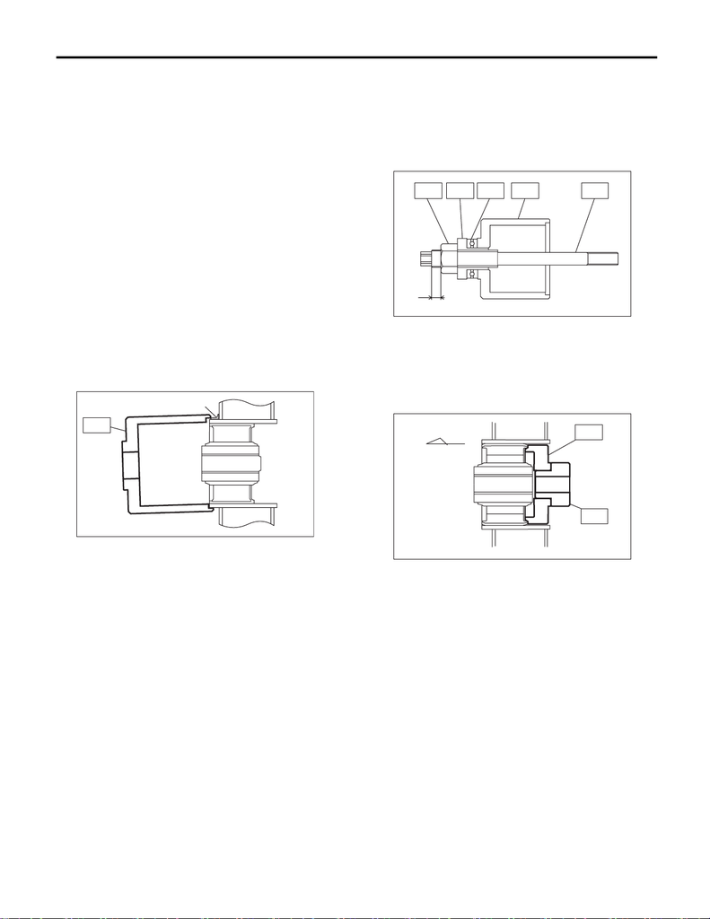

DI-57

Rear Differential Mount Bushing

DIFFERENTIALS

8. Rear Differential Mount Bush-

ing

A: INSPECTION

Check the rear differential mount bushing for

cracks, hardening or damage. If cracking, harden-

ing or damage is excessive, replace rear differen-

tial mount bushing.

B: REPLACEMENT

CAUTION:

• Apply the molybdenum grease on the square

thread of the ST (shaft and nut) before use.

• If there was so much rust in the rear differen-

tial mount bushing, remove the rust before

starting work.

1) Remove the rear differential. <Ref. to DI-19, RE-

MOVAL, Rear Differential (T-type).>

2) Fit the ST to the periphery of the sub frame cyl-

inder, and make sure that the ST does not contact

with welded spots or spatters.

ST 41399FG010 SPECIAL TOOL A

3) If the ST contacts with welded spots or spatters,

remove the excessive welds or spatters with sand-

er or the equivalent so that the ST contacts the cyl-

inder peripheral part.

CAUTION:

Performing the operation with the ST contact-

ing with welded spots or spatters may break the

ST. Be sure to remove excessive welds or spat-

ters before the operation.

4) Set ST1, ST2, ST3, ST4 and ST5 as shown in

the figure.

ST1 41399FG091 SPECIAL TOOL SHAFT

ST2 41399FG070 SPECIAL TOOL NUT

ST3 41399FG050 SPECIAL TOOL SLEEVE

ST4 41399FG080 SPECIAL TOOL BEARING

ST5 41399FG010 SPECIAL TOOL A

5) Fit and hold the ST1 and ST2 to the rear differ-

ential mount bushing from the rear side of vehicle.

ST1 41399FG031 SPECIAL TOOL C

ST2 41399FG061 SPECIAL TOOL RING

(A) Welded spot

DI-00655

ST

(A)

(A) 5 mm (0.2 in) or less

(A) Front side of vehicle

DI-00656

ST4

(A)

ST1ST2 ST3 ST5

DI-00657

(A)

ST2

ST1

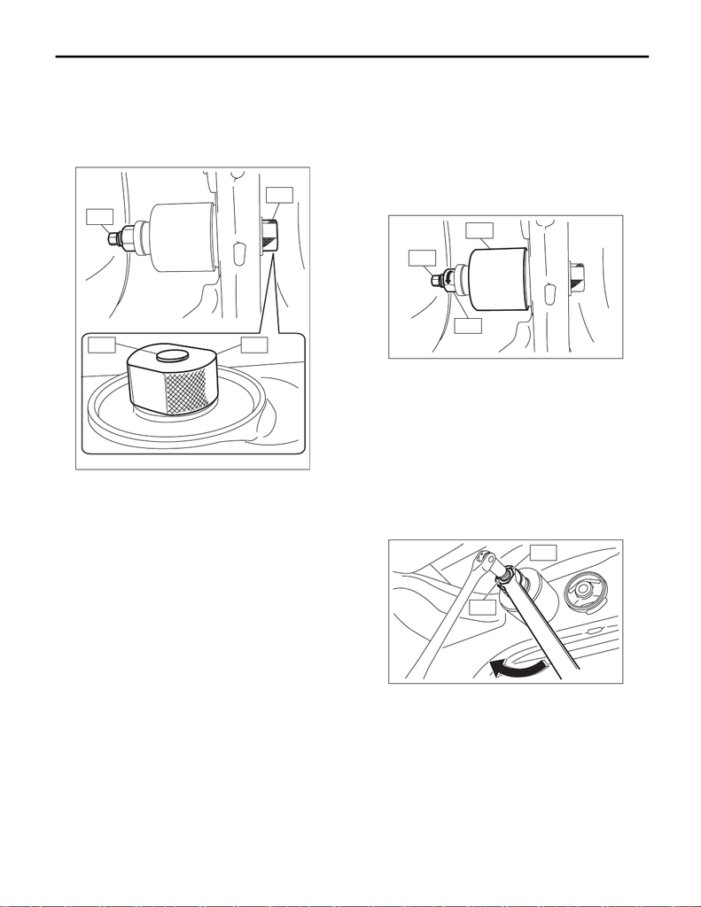

DI-58

Rear Differential Mount Bushing

DIFFERENTIALS

6) Insert the ST set in the step 4) through the rear

differential mount bushing hole from the front side

of vehicle, and screw in the ST1 by hand till the

front end of ST1 comes out slightly from the rear

end of ST2.

ST1 41399FG091 SPECIAL TOOL SHAFT

ST2 41399FG061 SPECIAL TOOL RING

7) Hold the ST1 to prevent it from rotating, and

screw in the ST3 by hand till there is no loose fit on

the ST2.

CAUTION:

When setting the ST to the vehicle, always

make sure that the ST2 fits the periphery of the

sub frame cylinder and is not tilted.

ST1 41399FG091 SPECIAL TOOL SHAFT

ST2 41399FG010 SPECIAL TOOL A

ST3 41399FG070 SPECIAL TOOL NUT

8) Hold the ST1 with a tool to prevent it from rotat-

ing, and screw in the ST2 to remove the rear differ-

ential mount bushing.

CAUTION:

• Rotation of ST1 will damage the screw at the

rear end of rear differential mount bushing.

Never rotate the ST1.

• If the ST starts to tilt while removing the rear

differential mount bushing, stop the work and

set the ST again.

ST1 41399FG091 SPECIAL TOOL SHAFT

ST2 41399FG070 SPECIAL TOOL NUT

DI-00708

ST1

ST1

ST2

ST2

DI-00659

ST1

ST3

ST2

DI-00660

ST2

ST1

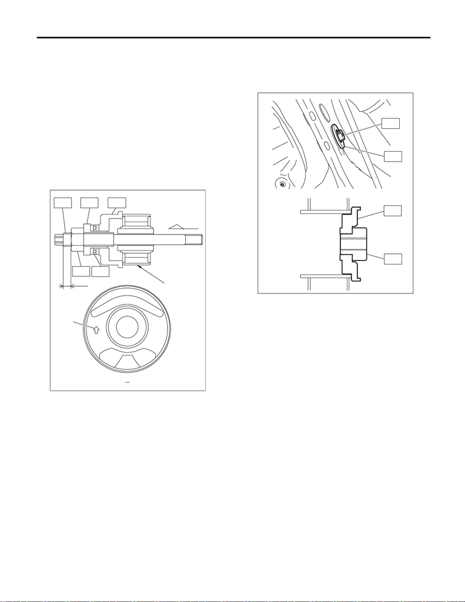

DI-59

Rear Differential Mount Bushing

DIFFERENTIALS

9) Set ST1, ST2, ST3, ST4, ST5 and rear differen-

tial mount bushing as shown in the figure.

NOTE:

• Set the ST2 nut near to the end of ST1 screw.

• Hold the rear differential mount bushing with the

arrow marked side facing toward the rear of the ve-

hicle, and set the rear differential mount bushing to

the ST so that the arrow mark faces upward.

• Mark the bottom end of rear differential mount

bushing to identify the installing direction.

ST1 41399FG091 SPECIAL TOOL SHAFT

ST2 41399FG070 SPECIAL TOOL NUT

ST3 41399FG050 SPECIAL TOOL SLEEVE

ST4 41399FG080 SPECIAL TOOL BEARING

ST5 41399FG020 SPECIAL TOOL B

10) Attach ST1 to the ST2, and fit and hold the STs

as a unit to the sub frame from the rear side of ve-

hicle.

ST1 41399FG061 SPECIAL TOOL RING

ST2 41399FG041 SPECIAL TOOL D

(A) 8 mm (0.31 in) or more

(B) Arrow mark

(C) Marked position

DI-01001

UP

Z

(B)

(C)

Z

ST1

ST2

ST3

ST4

ST5

(A)

DI-00662

ST1

ST2

ST2

ST1

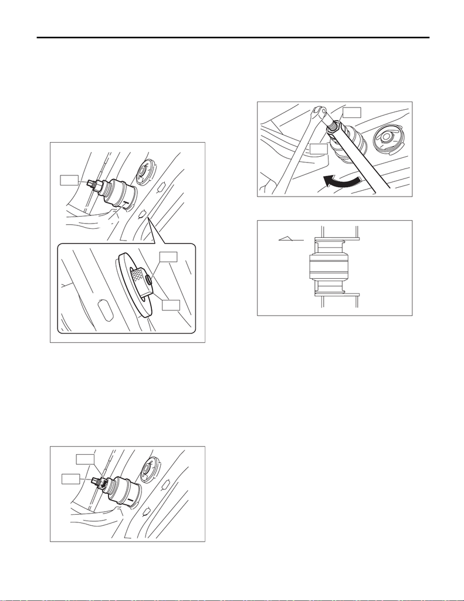

DI-60

Rear Differential Mount Bushing

DIFFERENTIALS

11) Insert the ST and rear differential mount bush-

ing set in the step 9) through the sub frame from the

front side of vehicle, and screw in the ST1 by hand

till the front end of ST1 comes out slightly from the

rear end of ST2.

CAUTION:

Set the rear differential mount bushing with its

mark facing the bottom end direction.

ST1 41399FG091 SPECIAL TOOL SHAFT

ST2 41399FG061 SPECIAL TOOL RING

12) Hold the ST1 to prevent it from rotating, and

screw in the ST2 by hand till there is no loose fit on

the ST and the rear differential mount bushing.

CAUTION:

Make sure that the ST and rear differential

mount bushing are not tilted.

ST1 41399FG091 SPECIAL TOOL SHAFT

ST2 41399FG070 SPECIAL TOOL NUT

13) Screw in the ST2 while holding the ST1 with a

tool to prevent it from rotating, and press-fit the rear

differential mount bushing to the front end of sub

frame cylinder.

ST1 41399FG091 SPECIAL TOOL SHAFT

ST2 41399FG070 SPECIAL TOOL NUT

14) Make sure that the rear differential mount bush-

ing is inserted to the front end of sub frame cylinder.

15) Install the rear differential. <Ref. to DI-21, IN-

STALLATION, Rear Differential (T-type).>

(A) Mark

DI-00977

(

A

)

ST2

ST1

ST1

DI-00664

ST2

ST1

(A) Front side of vehicle

DI-00665

ST2

ST1

DI-00666

(A)